# MIDUS Practice

# Read in the saved datafiles

```r
#install.packages(tidyverse)
#install.packages(descriptr)
#install.packages(mosaic)
library(tidyverse)
library(descriptr)
library(mosaic)
#Read data
MIDUS_short <- read_csv("MIDUS_practice.csv")
#Clean up missing values
MIDUS_short$A1SEMA[MIDUS_short$A1SEMA==9]<-NA
MIDUS_short$A1SSATIS[MIDUS_short$A1SSATIS==99]<-NA
MIDUS_short$A1PA44[MIDUS_short$A1PA44==997]<-NA
MIDUS_short$A1PA44[MIDUS_short$A1PA44==998]<-NA
MIDUS_short$A1PA44[MIDUS_short$A1PA44==999]<-NA
MIDUS_short
```

| A1SNEGAF | A1SSATIS | A1PA44 | A1SEMA |
| --- | --- | --- | --- |
| 1.167 | 7.750 | NA | 3.000 |
| NA | NA | NA | NA |
| 1.167 | 8.250 | NA | 3.679 |
| 1.000 | 9.750 | NA | 3.679 |
| 2.667 | 6.500 | NA | 2.464 |
| 2.500 | 7.500 | 60 | 2.893 |
| 1.667 | 9.000 | 20 | 2.607 |
| NA | NA | NA | NA |
| 1.000 | 6.125 | 40 | 3.679 |
| 1.333 | 7.750 | NA | 3.821 |

[output cut: 990 more lines]

# Variable desciptions

```
A1SNEGAF
BADMOOD - NEGATIVE AFFECT
Range of valid values: 1 - 5
```

```
**Scale**
A1SSATIS
LIFE SATISFACTION (5-ITEMS)
Range of valid values: 0 - 10
```

```
OUTCOME VARIABLE
A1PA44
AVE # CIGS PER DAY_CUR SMOKER
Question:
On average, about how many cigarettes did you smoke per day during the one year in your life
when you smoked most heavily?
```

```
A1SEMA
MATERNAL AFFECTION
Range of valid values: 1 - 4
```

# Create new maternal affection grouping variable

5. Create a new grouping variable that indicates whether participants report high or low levels of maternal affection. (Don’t overwrite the original maternal affection variable!)
- 1. Participants with maternal affection scores at least one standard deviation below the mean should receive a score of 1 on the grouping variable.
- 2. Participants with maternal affection scores at least one standard deviation above the mean should receive a score of 2 on the grouping variable.
- 3. Participants with maternal affection scores within one standard deviation of the mean should be labelled as missing (NA) on the grouping variable.
- 4. Hint: if your data contains missing values, you may need to include the argument na.rm=TRUE when the functions mean() or sd().
6. Convert the grouping variable into a factor with the levels “Low Maternal Affection” and “High Maternal Affection”

```r
MIDUS_short <- MIDUS_short %>%
  mutate(matAff = ifelse(zscore(MIDUS_short$A1SEMA, na.rm=TRUE) >=1, 2, NA)) %>% #High maternal Affection
   mutate(matAff = ifelse(zscore(MIDUS_short$A1SEMA, na.rm=TRUE) <  -1, 1, matAff), #Low maternal affection
  matAff.f = factor(matAff, levels = c(1,2),
                    labels = c("Low Maternal Affection", "High Maternal Affection")))
MIDUS_short
```

| A1SNEGAF | A1SSATIS | A1PA44 | A1SEMA | matAff | matAff.f |
| --- | --- | --- | --- | --- | --- |
| 1.167 | 7.750 | NA | 3.000 | NA | NA |
| NA | NA | NA | NA | NA | NA |
| 1.167 | 8.250 | NA | 3.679 | NA | NA |
| 1.000 | 9.750 | NA | 3.679 | NA | NA |
| 2.667 | 6.500 | NA | 2.464 | NA | NA |
| 2.500 | 7.500 | 60 | 2.893 | NA | NA |
| 1.667 | 9.000 | 20 | 2.607 | NA | NA |
| NA | NA | NA | NA | NA | NA |
| 1.000 | 6.125 | 40 | 3.679 | NA | NA |
| 1.333 | 7.750 | NA | 3.821 | NA | NA |

[output cut: 990 more lines]

# Filter the dataset to 1 above and 1 below SD on matAff

7. Filter any participants from your data who have missing values for the grouping variable you just created. (Hint: you may want to use the function is.na(), but there is more than 1 way to accomplish this step)

```r
MIDUS_filter1 <- MIDUS_short %>%
  filter(matAff != is.na(FALSE))
MIDUS_filter1
```

| A1SNEGAF | A1SSATIS | A1PA44 | A1SEMA | matAff | matAff.f |
| --- | --- | --- | --- | --- | --- |
| 1.667 | 6.125 | 30 | 2.357 | 1 | Low Maternal Affection |
| 1.667 | 7.000 | NA | 1.107 | 1 | Low Maternal Affection |
| 1.167 | 9.000 | NA | 1.643 | 1 | Low Maternal Affection |
| 1.167 | 8.667 | NA | 2.071 | 1 | Low Maternal Affection |
| 1.833 | 9.375 | NA | 1.500 | 1 | Low Maternal Affection |
| 2.667 | 6.500 | 35 | 3.964 | 2 | High Maternal Affection |
| 2.333 | 7.125 | 40 | 1.643 | 1 | Low Maternal Affection |
| 1.000 | 8.667 | NA | 1.357 | 1 | Low Maternal Affection |
| 2.000 | 8.125 | NA | 3.964 | 2 | High Maternal Affection |
| 1.833 | 5.500 | NA | 1.786 | 1 | Low Maternal Affection |

[output cut: 990 more lines]

```r
count(MIDUS_filter1)
```

| n |
| --- |
| 1844 |

# Create grouping variable where high or low satisfaction

8. Create a new grouping variable that indicates whether participants report high or low levels of life satisfaction. (Don’t overwrite the original life satisfaction variable!)
- 1. Participants with life satisfaction scores at least one standard deviation below the mean should receive a score of 1 on the grouping variable.
- 2. Participants with life satisfaction scores at least one standard deviation above the mean should receive a score of 2 on the grouping variable.
- 3. Participants with life satisfaction scores within one standard deviation of the mean should be labelled as missing (NA) on the grouping variable.
9. Convert the grouping variable into a factor with the levels “Low Life Satisfaction” and “High Life Satisfaction”

```r
MIDUS_filter1 <- MIDUS_filter1 %>%
  mutate(lifeSat = ifelse(zscore(MIDUS_filter1$A1SSATIS, na.rm=TRUE) >=1, 2, NA)) %>% #High life satisfaction
   mutate(lifeSat = ifelse(zscore(MIDUS_filter1$A1SSATIS, na.rm=TRUE) <  -1, 1, lifeSat), #Low maternal affection
  lifeSat.f = factor(lifeSat, levels = c(1,2),
                    labels = c("Low Life Satisfaction" , "High Life Satisfaction")))
MIDUS_filter1
```

| A1SNEGAF | A1SSATIS | A1PA44 | A1SEMA | matAff | matAff.f | lifeSat | lifeSat.f |
| --- | --- | --- | --- | --- | --- | --- | --- |
| 1.667 | 6.125 | 30 | 2.357 | 1 | Low Maternal Affection | 1 | Low Life Satisfaction |
| 1.667 | 7.000 | NA | 1.107 | 1 | Low Maternal Affection | NA | NA |
| 1.167 | 9.000 | NA | 1.643 | 1 | Low Maternal Affection | NA | NA |
| 1.167 | 8.667 | NA | 2.071 | 1 | Low Maternal Affection | NA | NA |
| 1.833 | 9.375 | NA | 1.500 | 1 | Low Maternal Affection | 2 | High Life Satisfaction |
| 2.667 | 6.500 | 35 | 3.964 | 2 | High Maternal Affection | NA | NA |
| 2.333 | 7.125 | 40 | 1.643 | 1 | Low Maternal Affection | NA | NA |
| 1.000 | 8.667 | NA | 1.357 | 1 | Low Maternal Affection | NA | NA |
| 2.000 | 8.125 | NA | 3.964 | 2 | High Maternal Affection | NA | NA |
| 1.833 | 5.500 | NA | 1.786 | 1 | Low Maternal Affection | 1 | Low Life Satisfaction |

[output cut: 990 more lines]

# Filter the dataset to 1 above and 1 below SD on lifeSat

10. Filter any participants from your data who have missing values for the grouping variable you just created.

```r
MIDUS_filter2 <- MIDUS_filter1 %>%
  filter(lifeSat != is.na(FALSE))
MIDUS_filter2
```

| A1SNEGAF | A1SSATIS | A1PA44 | A1SEMA | matAff | matAff.f | lifeSat | lifeSat.f |
| --- | --- | --- | --- | --- | --- | --- | --- |
| 1.667 | 6.125 | 30 | 2.357 | 1 | Low Maternal Affection | 1 | Low Life Satisfaction |
| 1.833 | 9.375 | NA | 1.500 | 1 | Low Maternal Affection | 2 | High Life Satisfaction |
| 1.833 | 5.500 | NA | 1.786 | 1 | Low Maternal Affection | 1 | Low Life Satisfaction |
| 1.000 | 9.333 | NA | 3.964 | 2 | High Maternal Affection | 2 | High Life Satisfaction |
| 3.333 | 4.667 | NA | 3.964 | 2 | High Maternal Affection | 1 | Low Life Satisfaction |
| 2.333 | 9.625 | NA | 3.964 | 2 | High Maternal Affection | 2 | High Life Satisfaction |
| 1.500 | 6.000 | NA | 1.357 | 1 | Low Maternal Affection | 1 | Low Life Satisfaction |
| 1.500 | 9.250 | NA | 1.786 | 1 | Low Maternal Affection | 2 | High Life Satisfaction |
| 1.000 | 9.750 | NA | 3.964 | 2 | High Maternal Affection | 2 | High Life Satisfaction |
| 2.000 | 9.500 | 20 | 3.964 | 2 | High Maternal Affection | 2 | High Life Satisfaction |

[output cut: 516 more lines]

```r
count(MIDUS_filter2)
```

| n |
| --- |
| 526 |

# subset dataset

Subset your data so that it only contains maternal affection, your maternal affection grouping variable, life satisfaction, your life satisfaction grouping variable, and number of cigarettes smoked.

```r
MIDUS_select<- select(MIDUS_filter2, A1SSATIS:matAff.f, lifeSat, lifeSat.f)
MIDUS_select
```

| A1SSATIS | A1PA44 | A1SEMA | matAff | matAff.f | lifeSat | lifeSat.f |
| --- | --- | --- | --- | --- | --- | --- |
| 6.125 | 30 | 2.357 | 1 | Low Maternal Affection | 1 | Low Life Satisfaction |
| 9.375 | NA | 1.500 | 1 | Low Maternal Affection | 2 | High Life Satisfaction |
| 5.500 | NA | 1.786 | 1 | Low Maternal Affection | 1 | Low Life Satisfaction |
| 9.333 | NA | 3.964 | 2 | High Maternal Affection | 2 | High Life Satisfaction |
| 4.667 | NA | 3.964 | 2 | High Maternal Affection | 1 | Low Life Satisfaction |
| 9.625 | NA | 3.964 | 2 | High Maternal Affection | 2 | High Life Satisfaction |
| 6.000 | NA | 1.357 | 1 | Low Maternal Affection | 1 | Low Life Satisfaction |
| 9.250 | NA | 1.786 | 1 | Low Maternal Affection | 2 | High Life Satisfaction |
| 9.750 | NA | 3.964 | 2 | High Maternal Affection | 2 | High Life Satisfaction |
| 9.500 | 20 | 3.964 | 2 | High Maternal Affection | 2 | High Life Satisfaction |

[output cut: 516 more lines]

# Filter by cigarette data

12. Filter any participants from your data who have missing values for number of cigarettes smoked per day.

```r
MIDUS_FINAL<- MIDUS_select %>%
  filter(A1PA44 != is.na(FALSE))
MIDUS_FINAL
```

| A1SSATIS | A1PA44 | A1SEMA | matAff | matAff.f | lifeSat | lifeSat.f |
| --- | --- | --- | --- | --- | --- | --- |
| 6.125 | 30 | 2.357 | 1 | Low Maternal Affection | 1 | Low Life Satisfaction |
| 9.500 | 20 | 3.964 | 2 | High Maternal Affection | 2 | High Life Satisfaction |
| 5.500 | 20 | 2.036 | 1 | Low Maternal Affection | 1 | Low Life Satisfaction |
| 5.000 | 40 | 1.393 | 1 | Low Maternal Affection | 1 | Low Life Satisfaction |
| 4.000 | 60 | 2.214 | 1 | Low Maternal Affection | 1 | Low Life Satisfaction |
| 3.250 | 30 | 3.964 | 2 | High Maternal Affection | 1 | Low Life Satisfaction |
| 5.000 | 18 | 2.036 | 1 | Low Maternal Affection | 1 | Low Life Satisfaction |
| 10.000 | 20 | 2.286 | 1 | Low Maternal Affection | 2 | High Life Satisfaction |
| 5.333 | 15 | 2.071 | 1 | Low Maternal Affection | 1 | Low Life Satisfaction |
| 10.000 | 20 | 3.964 | 2 | High Maternal Affection | 2 | High Life Satisfaction |

[output cut: 122 more lines]

```r
count(MIDUS_FINAL)
```

| n |
| --- |
| 132 |

# Box plots grouped by maternal affection

13. Create a boxplot with maternal affection group on the x-axis and cigarettes on the y-axis.
- 1. Add an appropriate title and axis labels

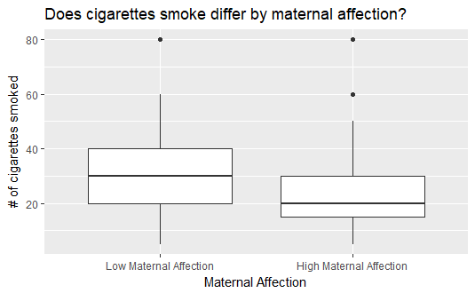

```r
ggplot(MIDUS_FINAL, aes(x = matAff.f, y= A1PA44, group = matAff.f)) +
  geom_boxplot(show.legend = FALSE) +
  labs(title= "Does cigarettes smoke differ by maternal affection?", x = "Maternal Affection", y = "# of cigarettes smoked")
```

# Box plots grouped by Life satsfication

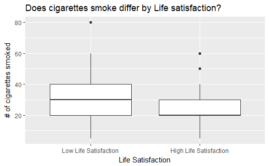

```r
ggplot(MIDUS_FINAL, aes(x = lifeSat.f, y= A1PA44, group = lifeSat.f)) +
  geom_boxplot(show.legend = FALSE) +
  labs(title= "Does cigarettes smoke differ by Life satisfaction?", x = "Life Satisfaction", y = "# of cigarettes smoked")
```